# Lecture_5Rcode

Nemanja Vaci

March 10, 2021

Simulating new dataset that is hierarchicaly structured

```r
set.seed(456)
#Specifying population level values - true values that we are trying to estimate

#Fixed effects
alpha_0 <-400 #intercept value
beta_1 <-20 #slope
sigma <- 5 #sd of response

#Specification of the between group variation

# by-intercept sd, by_slope sd and correlation between intercept and slope
tau_0 <- 50 # by-group random intercet (countries)

tau_1 <- 10 # by-group random slope (countries)
rho <- -.3

n_countries<-10 #number of countries from which our babies are coming

countries_rfx <- faux::rnorm_multi(
  n=n_countries,
  mu = 0,
  sd = c(tau_0, tau_1),
  r = rho,
  varnames = c('T_0s','T_1s')
) #simulation of the multinormal distribution, where we have number of values equal to our countries. Mean is at 0 while we have two SD values for our intercept and slope adjustments

babies_rfx=data.frame(T_0s=rep(countries_rfx$T_0s, each=20), T_1s=rep(countries_rfx$T_1s, each=20)) # We are going to repeat this information 20 times for each value, as we would like to sample 20 babies from each country

Babies <- data.frame(Country_id = rep(1:10, each=20),
babies_rfx) #Combining this in the new data frame, where we have id for each country as a first variable

#Simulation of other predictors
Babies$Age=round(runif(200,1,30))
Babies$Weight=rnorm(200,4000,500)
Babies$Gender=rbinom(200,1,0.5)
Babies$Gender=as.factor(Babies$Gender)
levels(Babies$Gender)=c('Girls','Boys')
#Simulation of the running distance where we specify all values on which distance depends. We have alpha_0 - intercept + T_0S - adjustments for intercept (country-level differences) + (beta_1 - slope + T_1s - adjustments for slope (country-level differences))*Babies$Age - our predictor, sigma - standard deviation for our values)
Babies$RunningDist=rnorm(200,alpha_0 + Babies$T_0s+(beta_1+Babies$T_1s)*Babies$Age, sigma)
Babies$Country_id=as.factor(Babies$Country_id)
```

```r
table(Babies$Country_id) #How many observations we have for each group
```

```
##
##  1  2  3  4  5  6  7  8  9 10
## 20 20 20 20 20 20 20 20 20 20
```

Linear model: complete pooling

```r
mod1CP<-lm(RunningDist~Age, data=Babies)
summary(mod1CP)
```

```
##
## Call:
## lm(formula = RunningDist ~ Age, data = Babies)
##
## Residuals:
##     Min      1Q  Median      3Q     Max
## -309.65 -127.68  -39.48   76.39  622.61
##
## Coefficients:
##             Estimate Std. Error t value Pr(>|t|)
## (Intercept)  387.262     29.575  13.094  < 2e-16 ***
## Age           11.695      1.643   7.116 1.99e-11 ***
## ---
## Signif. codes:  0 '***' 0.001 '**' 0.01 '*' 0.05 '.' 0.1 ' ' 1
##
## Residual standard error: 195.4 on 198 degrees of freedom
## Multiple R-squared:  0.2037, Adjusted R-squared:  0.1996
## F-statistic: 50.64 on 1 and 198 DF,  p-value: 1.991e-11
```

Residual plot

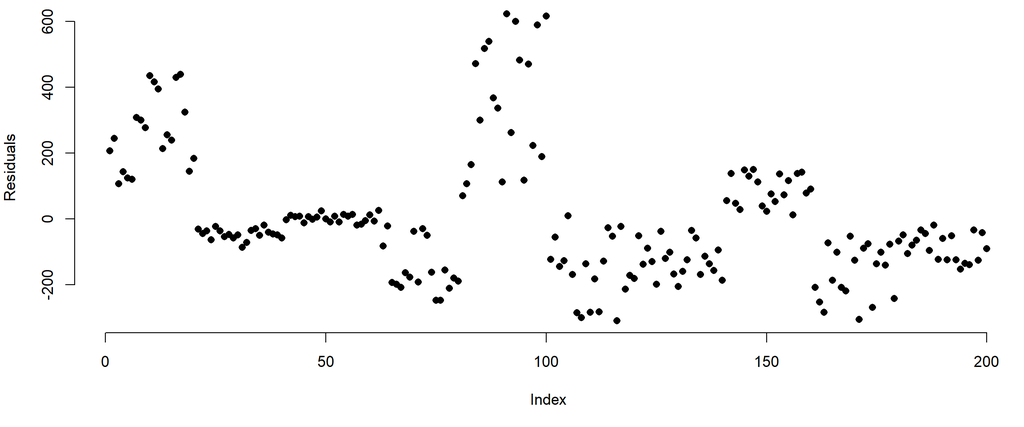

```r
par(mfrow=c(1,1), bty='n',mar = c(5, 4, .1, .1), cex=1.1, pch=16)
plot(resid(mod1CP), ylab='Residuals', xlab='Index')
```

Linear model: no pooling

```r
mod1NP<-lm(RunningDist~Age+factor(Country_id)-1, data=Babies)
summary(mod1NP)
```

```
##
## Call:
## lm(formula = RunningDist ~ Age + factor(Country_id) - 1, data = Babies)
##
## Residuals:
##      Min       1Q   Median       3Q      Max
## -282.176  -46.913   -2.057   41.743  259.480
##
## Coefficients:
##                      Estimate Std. Error t value Pr(>|t|)
## Age                   12.0933     0.7851  15.404   <2e-16 ***
## factor(Country_id)1  646.5979    23.0742  28.023   <2e-16 ***
## factor(Country_id)2  335.1276    22.7026  14.762   <2e-16 ***
## factor(Country_id)3  381.3623    25.4322  14.995   <2e-16 ***
## factor(Country_id)4  243.0205    24.8691   9.772   <2e-16 ***
## factor(Country_id)5  738.8460    23.6285  31.269   <2e-16 ***
## factor(Country_id)6  220.8993    24.0903   9.170   <2e-16 ***
## factor(Country_id)7  256.4331    24.0903  10.645   <2e-16 ***
## factor(Country_id)8  469.6384    23.9834  19.582   <2e-16 ***
## factor(Country_id)9  221.2246    22.3018   9.920   <2e-16 ***
## factor(Country_id)10 296.1329    23.4261  12.641   <2e-16 ***
## ---
## Signif. codes:  0 '***' 0.001 '**' 0.01 '*' 0.05 '.' 0.1 ' ' 1
##
## Residual standard error: 90.15 on 189 degrees of freedom
## Multiple R-squared:  0.9796, Adjusted R-squared:  0.9784
## F-statistic: 824.4 on 11 and 189 DF,  p-value: < 2.2e-16
```

Residual plot

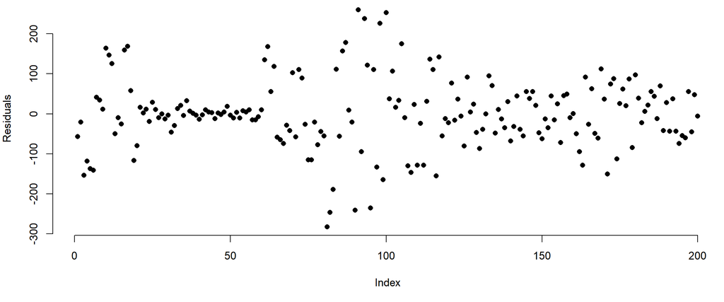

```r
par(mfrow=c(1,1), bty='n',mar = c(5, 4, .1, .1), cex=1.1, pch=16)
plot(resid(mod1NP), ylab='Residuals',xlab='Index')
```

Linear mixed-effect model: intercept adjustment

```r
#install.packages('lme4')
require(lme4)

mult1<-lmer(RunningDist~Age+(1|Country_id), data=Babies)
summary(mult1)
```

```
## Linear mixed model fit by REML ['lmerMod']
## Formula: RunningDist ~ Age + (1 | Country_id)
##    Data: Babies
##
## REML criterion at convergence: 2399
##
## Scaled residuals:
##      Min       1Q   Median       3Q      Max
## -3.08265 -0.51390 -0.02426  0.47520  2.92714
##
## Random effects:
##  Groups     Name        Variance Std.Dev.
##  Country_id (Intercept) 33092    181.91
##  Residual                8128     90.15
## Number of obs: 200, groups:  Country_id, 10
##
## Fixed effects:
##             Estimate Std. Error t value
## (Intercept) 381.0106    59.2094   6.435
## Age          12.0881     0.7847  15.404
##
## Correlation of Fixed Effects:
##     (Intr)
## Age -0.211
```

Linear mixed-effect model: slope for Age predictor adjustment and intercept adjustment for each country

```r
mult2<-lmer(RunningDist~Age+(1+Age|Country_id), data=Babies)
summary(mult2)
```

```
## Linear mixed model fit by REML ['lmerMod']
## Formula: RunningDist ~ Age + (1 + Age | Country_id)
##    Data: Babies
##
## REML criterion at convergence: 1349.4
##
## Scaled residuals:
##     Min      1Q  Median      3Q     Max
## -2.4137 -0.6028 -0.0925  0.6037  3.3570
##
## Random effects:
##  Groups     Name        Variance Std.Dev. Corr
##  Country_id (Intercept) 2010.65  44.840
##             Age          111.93  10.580   0.33
##  Residual                 23.93   4.892
## Number of obs: 200, groups:  Country_id, 10
##
## Fixed effects:
##             Estimate Std. Error t value
## (Intercept)  399.652     14.202   28.14
## Age           11.008      3.346    3.29
##
## Correlation of Fixed Effects:
##     (Intr)
## Age 0.330
```

Fixed-effects:

```r
fixef(mult2)
```

```
## (Intercept)         Age
##   399.65175    11.00775
```

Random effects

```r
ranef(mult2)
```

```
## $Country_id
##    (Intercept)        Age
## 1     69.57041  13.487071
## 2    -29.63758  -1.536129
## 3    -37.81309   2.075458
## 4     67.50182 -11.000094
## 5     38.32357  20.248860
## 6     17.97654 -10.625830
## 7    -32.89473  -5.480356
## 8    -14.06215   6.164935
## 9    -48.00096  -9.647232
## 10   -30.96383  -3.686683
##
## with conditional variances for "Country_id"
```

No pooling model with Age*factor interaction:

```r
mod1NP2<-lm(RunningDist~Age*factor(Country_id)-1, data=Babies)
summary(mod1NP2)[4]
```

```
## $coefficients
##                            Estimate Std. Error    t value      Pr(>|t|)
## Age                       24.489579  0.1273112  192.35994 2.623964e-210
## factor(Country_id)1      469.331037  2.1238473  220.98153 4.179553e-221
## factor(Country_id)2      369.926521  2.3538825  157.15590 1.337919e-194
## factor(Country_id)3      361.521752  3.5548706  101.69758 5.775693e-161
## factor(Country_id)4      467.649653  3.0302334  154.32793 3.431913e-193
## factor(Country_id)5      437.964345  2.0929519  209.25677 7.352799e-217
## factor(Country_id)6      417.770998  2.4320250  171.77907 1.648858e-201
## factor(Country_id)7      366.677101  2.5114917  145.99973 6.886336e-189
## factor(Country_id)8      385.492273  2.4490023  157.40789 1.004817e-194
## factor(Country_id)9      351.585467  2.0343006  172.82867 5.544225e-202
## factor(Country_id)10     368.627039  2.1004179  175.50176 3.556781e-203
## Age:factor(Country_id)2  -15.012744  0.2019115  -74.35308 4.665983e-137
## Age:factor(Country_id)3  -11.391698  0.2133982  -53.38236 2.727194e-112
## Age:factor(Country_id)4  -24.505671  0.1985354 -123.43222 6.831701e-176
## Age:factor(Country_id)5    6.768155  0.1706634   39.65791  6.865861e-91
## Age:factor(Country_id)6  -24.114839  0.1814550 -132.89708 1.322168e-181
## Age:factor(Country_id)7  -18.958425  0.1852506 -102.33933 1.897456e-161
## Age:factor(Country_id)8   -7.311926  0.1836773  -39.80855  3.719432e-91
## Age:factor(Country_id)9  -23.125574  0.1900993 -121.64998 9.080362e-175
## Age:factor(Country_id)10 -17.165635  0.1735666  -98.89943 8.025977e-159
```

Residuals (no pooling versus mixed-effect model)

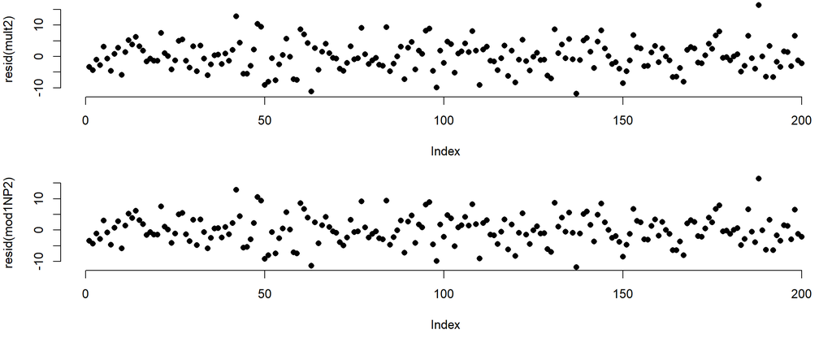

```r
par(mfrow=c(2,1), bty='n',mar = c(5, 4, .1, .1), cex=1.1,pch=16)
plot(resid(mult2))
plot(resid(mod1NP2))
```

Random intercepts and slopes adjustments for Age predictor for country factor

```r
mult2<-lmer(RunningDist~Age+(1+Age|Country_id), data=Babies)
print(summary(mult2), cor=F)
```

```
## Linear mixed model fit by REML ['lmerMod']
## Formula: RunningDist ~ Age + (1 + Age | Country_id)
##    Data: Babies
##
## REML criterion at convergence: 1349.4
##
## Scaled residuals:
##     Min      1Q  Median      3Q     Max
## -2.4137 -0.6028 -0.0925  0.6037  3.3570
##
## Random effects:
##  Groups     Name        Variance Std.Dev. Corr
##  Country_id (Intercept) 2010.65  44.840
##             Age          111.93  10.580   0.33
##  Residual                 23.93   4.892
## Number of obs: 200, groups:  Country_id, 10
##
## Fixed effects:
##             Estimate Std. Error t value
## (Intercept)  399.652     14.202   28.14
## Age           11.008      3.346    3.29
```

Statistical significance of the predictors:

```r
#install.packages('lmerTest')
require(lmerTest) #we need lmerTest and to rerun the model to get p-values
mult2<-lmer(RunningDist~Age+(1+Age|Country_id), data=Babies)
print(summary(mult2), cor=F)
```

```
## Linear mixed model fit by REML. t-tests use Satterthwaite's method [
## lmerModLmerTest]
## Formula: RunningDist ~ Age + (1 + Age | Country_id)
##    Data: Babies
##
## REML criterion at convergence: 1349.4
##
## Scaled residuals:
##     Min      1Q  Median      3Q     Max
## -2.4137 -0.6028 -0.0925  0.6037  3.3570
##
## Random effects:
##  Groups     Name        Variance Std.Dev. Corr
##  Country_id (Intercept) 2010.65  44.840
##             Age          111.93  10.580   0.33
##  Residual                 23.93   4.892
## Number of obs: 200, groups:  Country_id, 10
##
## Fixed effects:
##             Estimate Std. Error      df t value Pr(>|t|)
## (Intercept)  399.652     14.202   8.998   28.14 4.41e-10 ***
## Age           11.008      3.346   9.001    3.29  0.00938 **
## ---
## Signif. codes:  0 '***' 0.001 '**' 0.01 '*' 0.05 '.' 0.1 ' ' 1
```

Practical aspect

```r
#install.packages('foreign')
require(foreign) #to read-in the data that are SPSS format (.sav) we need foreign package
mwell<-read.spss('data.sav', to.data.frame = T) #read.spss function and we specify that we should read it as a data frame
dim(mwell) #dimensions of our data (number of rows and columns)
```

```
## [1] 120115     74
```

```r
mwell$Total=mwell$Watchwe_adj+mwell$Watchwk_adj+mwell$Comphwe_adj+mwell$Comphwk_adj+mwell$Smartwe_adj+mwell$Smartwk_adj #total amount of time spent watching screen in a week
```

Number of missing values in our outcome:

```r
table(is.na(mwell$mwb))
```

```
##
##  FALSE   TRUE
## 102580  17535
```

Numbe of missing values in our predictor:

```r
table(is.na(mwell$Watchwk))
```

```
##
##  FALSE   TRUE
## 117638   2477
```

Density plots for our variables

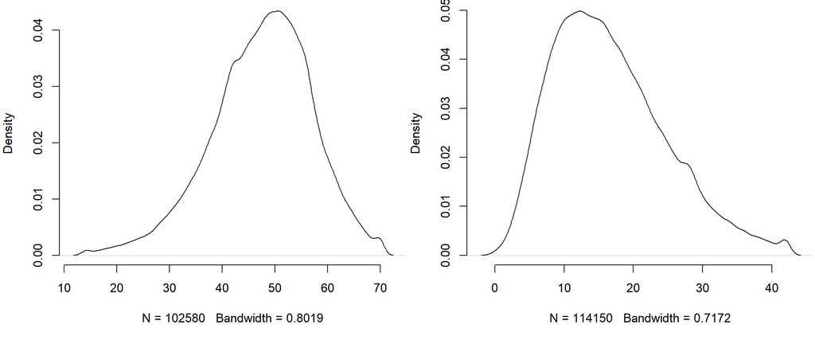

```r
par(mfrow=c(1,2), bty='n',mar = c(5, 4, .1, .1), cex=1.1,pch=16)
plot(density(mwell$mwb, na.rm=TRUE), main='')
plot(density(mwell$Total, na.rm = T), main='')
```

Subsetting the data - excluding NAs:

```r
mwell2=mwell[!is.na(mwell$mwb) & !is.na(mwell$Total),] # we are trying to subset our data frame and take only values that are not NAs. is.na is a boolean function that tells us whether one row is NA or not (TRUE or FALSE). !is.na indicates that we do not want TRUE na.values. We also have a logical parameter & that combines two conditions !is.na(outcome) & !is.na(predictor). Finally, we would like to filter our dataset by row and exclude all the rows that have either TRUE value in our predictor or our outcome. Therefore, we are looking at rows mwell[function goes here,] instead of mwell[,function goes here ] which would look at columns
dim(mwell2) #dimensions of the smaller data
```

```
## [1] 98853    75
```

Scatter plot:

```r
cor(mwell2$mwb, mwell2$Total)
```

```
## [1] -0.1724534
```

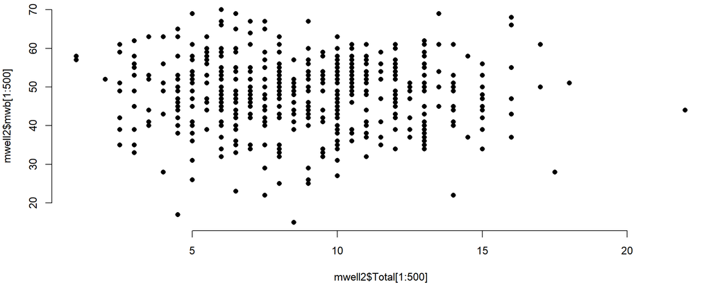

```r
par(mfrow=c(1,1), bty='n',mar = c(5, 4, .1, .1), cex=1.1,pch=16)
plot(mwell2$Total[1:500], mwell2$mwb[1:500])
```

Number of observations for each of our potential random structures:

```r
table(mwell2$Ethnicg)
```

```
##
##            White            Mixed            Asian            Black
##            76428             3827             9537             4413
## Other or unknown
##             4648
```

```r
table(mwell2$REGION)
```

```
##
## East Midlands
##                                                                     6440
## East of England
##                                                                     7612
## London
##                                                                    18524
## North East
##                                                                     6826
## North West
##                                                                    15276
## South East
##                                                                    13160
## South West
##                                                                    10105
## West Midlands
##                                                                    10328
## Yorkshire and the Humber
##                                                                    10582
```

Building the model:

```r
MWmod1<-lmer(mwb~(1|LANAME), data=mwell2) #random effect of Local area
MWmod2<-lmer(mwb~(1|LANAME)+(1|Ethnicg), data=mwell2) #crossed random effects of local area and ethnicity
MWmod3<-lmer(mwb~(1|REGION/LANAME)+(1|Ethnicg), data=mwell2) #nested random effect of local area that is nested in region and crossed with ethnicity
anova(MWmod1, MWmod2, MWmod3) #comparison of the models
```

```
## refitting model(s) with ML (instead of REML)
```

```
## Data: mwell2
## Models:
## MWmod1: mwb ~ (1 | LANAME)
## MWmod2: mwb ~ (1 | LANAME) + (1 | Ethnicg)
## MWmod3: mwb ~ (1 | REGION/LANAME) + (1 | Ethnicg)
##        npar    AIC    BIC  logLik deviance  Chisq Df Pr(>Chisq)
## MWmod1    3 726331 726359 -363162   726325
## MWmod2    4 726326 726364 -363159   726318 7.1022  1   0.007699 **
## MWmod3    5 726323 726371 -363157   726313 4.2095  1   0.040198 *
## ---
## Signif. codes:  0 '***' 0.001 '**' 0.01 '*' 0.05 '.' 0.1 ' ' 1
```

Building the model: Fixed structure 1

```r
MWmod2a<-lmer(mwb~Total+(1|LANAME)+(1|Ethnicg), data=mwell2) #main effect of total
print(summary(MWmod2a), cor=F)
```

```
## Linear mixed model fit by REML. t-tests use Satterthwaite's method [
## lmerModLmerTest]
## Formula: mwb ~ Total + (1 | LANAME) + (1 | Ethnicg)
##    Data: mwell2
##
## REML criterion at convergence: 723288.3
##
## Scaled residuals:
##     Min      1Q  Median      3Q     Max
## -4.0004 -0.6215  0.0686  0.6822  3.0084
##
## Random effects:
##  Groups   Name        Variance Std.Dev.
##  LANAME   (Intercept)  0.2160  0.4647
##  Ethnicg  (Intercept)  0.2936  0.5418
##  Residual             87.9915  9.3804
## Number of obs: 98853, groups:  LANAME, 150; Ethnicg, 5
##
## Fixed effects:
##               Estimate Std. Error         df t value Pr(>|t|)
## (Intercept)  5.109e+01  2.594e-01  4.583e+00  196.96 3.53e-10 ***
## Total       -2.054e-01  3.695e-03  9.801e+04  -55.59  < 2e-16 ***
## ---
## Signif. codes:  0 '***' 0.001 '**' 0.01 '*' 0.05 '.' 0.1 ' ' 1
```

Building the model: Fixed structure 2

```r
MWmod2b<-lmer(mwb~Total+male+(1|LANAME)+(1|Ethnicg), data=mwell2) #main effect of total and main effect of sex
MWmod2c<-lmer(mwb~Total*male+(1|LANAME)+(1|Ethnicg), data=mwell2) #interaction between total and sex
anova(MWmod2a, MWmod2b, MWmod2c)#comparison of the models
```

```
## refitting model(s) with ML (instead of REML)
```

```
## Data: mwell2
## Models:
## MWmod2a: mwb ~ Total + (1 | LANAME) + (1 | Ethnicg)
## MWmod2b: mwb ~ Total + male + (1 | LANAME) + (1 | Ethnicg)
## MWmod2c: mwb ~ Total * male + (1 | LANAME) + (1 | Ethnicg)
##         npar    AIC    BIC  logLik deviance   Chisq Df Pr(>Chisq)
## MWmod2a    5 723288 723335 -361639   723278
## MWmod2b    6 717197 717254 -358592   717185 6093.02  1  < 2.2e-16 ***
## MWmod2c    7 716978 717044 -358482   716964  221.25  1  < 2.2e-16 ***
## ---
## Signif. codes:  0 '***' 0.001 '**' 0.01 '*' 0.05 '.' 0.1 ' ' 1
```

```r
print(summary(MWmod2c), cor=F)
```

```
## Linear mixed model fit by REML. t-tests use Satterthwaite's method [
## lmerModLmerTest]
## Formula: mwb ~ Total * male + (1 | LANAME) + (1 | Ethnicg)
##    Data: mwell2
##
## REML criterion at convergence: 716985.8
##
## Scaled residuals:
##     Min      1Q  Median      3Q     Max
## -4.1959 -0.6181  0.0586  0.6695  3.3167
##
## Random effects:
##  Groups   Name        Variance Std.Dev.
##  LANAME   (Intercept)  0.1892  0.4349
##  Ethnicg  (Intercept)  0.3367  0.5802
##  Residual             82.5528  9.0859
## Number of obs: 98853, groups:  LANAME, 150; Ethnicg, 5
##
## Fixed effects:
##                 Estimate Std. Error         df t value Pr(>|t|)
## (Intercept)    4.884e+01  2.835e-01  5.101e+00  172.26 8.42e-11 ***
## Total         -1.979e-01  4.928e-03  9.864e+04  -40.17  < 2e-16 ***
## maleYes        2.921e+00  1.328e-01  9.881e+04   21.99  < 2e-16 ***
## Total:maleYes  1.084e-01  7.285e-03  9.880e+04   14.88  < 2e-16 ***
## ---
## Signif. codes:  0 '***' 0.001 '**' 0.01 '*' 0.05 '.' 0.1 ' ' 1
```

Random structure: random slopes

```r
MWmod3c<-lmer(mwb~Total*male+(1+Total|LANAME)+(1|Ethnicg), data=mwell2) #random slopes for total predictor for Local area and intercept for local area
MWmod3c<-lmer(mwb~Total*male+(1|LANAME:male)+(1|Ethnicg), data=mwell2) #random intercept for unique combination between local area and sex
anova(MWmod2c, MWmod3c) #comparison of the models
```

```
## refitting model(s) with ML (instead of REML)
```

```
## Data: mwell2
## Models:
## MWmod2c: mwb ~ Total * male + (1 | LANAME) + (1 | Ethnicg)
## MWmod3c: mwb ~ Total * male + (1 | LANAME:male) + (1 | Ethnicg)
##         npar    AIC    BIC  logLik deviance Chisq Df Pr(>Chisq)
## MWmod2c    7 716978 717044 -358482   716964
## MWmod3c    7 716995 717062 -358491   716981     0  0
```

```r
MWmod3c<-lmer(mwb~Total*male+(1|LANAME)+(1|Ethnicg:male), data=mwell2) #random intercepts for unique combination between Ethnicity and sex
anova(MWmod2c, MWmod3c)
```

```
## refitting model(s) with ML (instead of REML)
```

```
## Data: mwell2
## Models:
## MWmod2c: mwb ~ Total * male + (1 | LANAME) + (1 | Ethnicg)
## MWmod3c: mwb ~ Total * male + (1 | LANAME) + (1 | Ethnicg:male)
##         npar    AIC    BIC  logLik deviance Chisq Df Pr(>Chisq)
## MWmod2c    7 716978 717044 -358482   716964
## MWmod3c    7 716955 717022 -358471   716941 22.41  0
```

```r
summary(MWmod3)
```

```
## Linear mixed model fit by REML. t-tests use Satterthwaite's method [
## lmerModLmerTest]
## Formula: mwb ~ (1 | REGION/LANAME) + (1 | Ethnicg)
##    Data: mwell2
##
## REML criterion at convergence: 726315.4
##
## Scaled residuals:
##     Min      1Q  Median      3Q     Max
## -3.6003 -0.6199  0.0771  0.6881  2.4872
##
## Random effects:
##  Groups        Name        Variance Std.Dev.
##  LANAME:REGION (Intercept)  0.18076 0.4252
##  REGION        (Intercept)  0.03315 0.1821
##  Ethnicg       (Intercept)  0.08082 0.2843
##  Residual                  90.74939 9.5262
## Number of obs: 98853, groups:  LANAME:REGION, 150; REGION, 9; Ethnicg, 5
##
## Fixed effects:
##             Estimate Std. Error      df t value Pr(>|t|)
## (Intercept)  47.5569     0.1568  5.2742   303.3 2.16e-12 ***
## ---
## Signif. codes:  0 '***' 0.001 '**' 0.01 '*' 0.05 '.' 0.1 ' ' 1
## optimizer (nloptwrap) convergence code: 0 (OK)
## Model failed to converge with max|grad| = 0.00241727 (tol = 0.002, component 1)
```

Visualisation of the random structure:

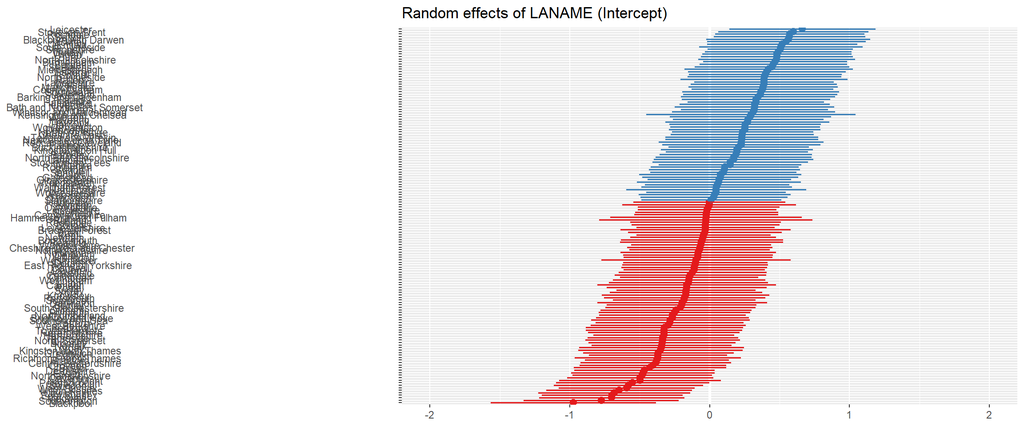

```r
require(sjPlot)
plot_model(MWmod3c, type='re', sort.est='sort.all', grid=FALSE)[1] #type='re' gives us random adjustments, while [1] indicates that we want only first plot
```

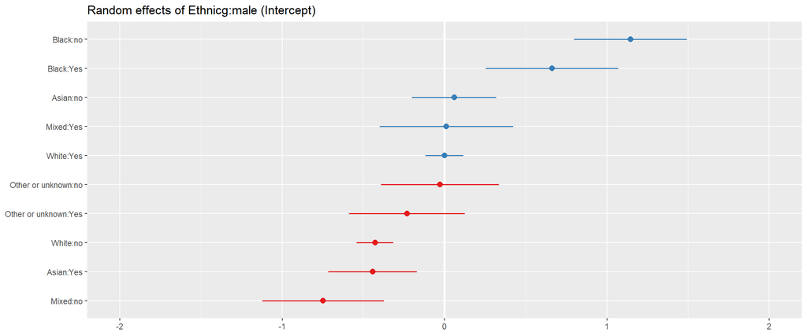

```r
plot_model(MWmod3c, type='re', sort.est='sort.all', grid=FALSE)[2]
```

Visualisation of the fixed effects (interaction):

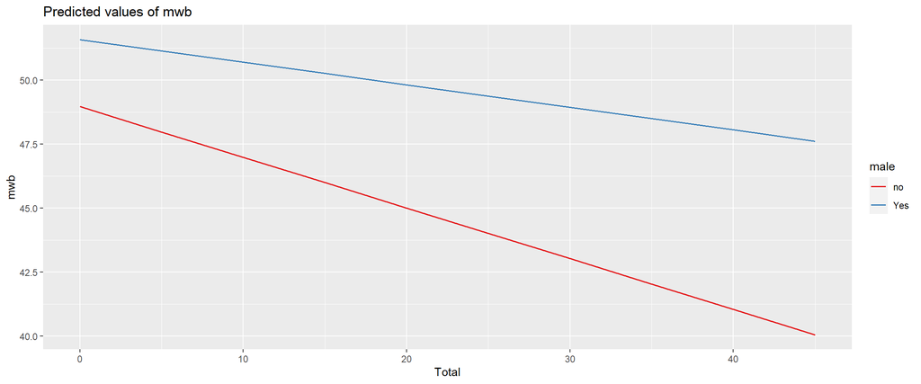

```r
plot_model(MWmod3c, type='int')
```

Significance of the random effects

```r
ranova(MWmod3c)
```

```
## ANOVA-like table for random-effects: Single term deletions
##
## Model:
## mwb ~ Total + male + (1 | LANAME) + (1 | Ethnicg:male) + Total:male
##                    npar  logLik    AIC    LRT Df Pr(>Chisq)
## <none>                7 -358480 716974
## (1 | LANAME)          6 -358523 717059 86.708  1  < 2.2e-16 ***
## (1 | Ethnicg:male)    6 -358525 717061 88.990  1  < 2.2e-16 ***
## ---
## Signif. codes:  0 '***' 0.001 '**' 0.01 '*' 0.05 '.' 0.1 ' ' 1
```

Explained variance - R2

```r
#install.packages('MuMIn')
require(MuMIn)
r.squaredGLMM(MWmod3c) # m stands for marginal, while c stands for conditional. Marginal is approximation of the explained variance by fixed-effect structure, while conditional is with both fixed and random-effect structure
```

```
##             R2m        R2c
## [1,] 0.08319687 0.08936068
```

Predictions of the model

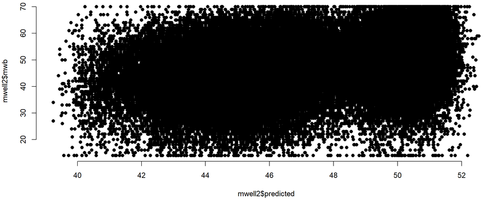

```r
mwell2$predicted=predict(MWmod3c) #prediction values from model to our train dataset
par(mfrow=c(1,1), bty='n',mar = c(5, 4, .1, .1), cex=1.1,pch=16)
plot(mwell2$predicted, mwell2$mwb) #plot predicted versus observed data points
```